# Strengthen & Deploy

Learning outcomes - Debug Shiny apps and understand them from the inside - Supervise and test Shiny apps for robustness (appendix) - Convert simple Shiny apps to static website using shinylive - Deploy any Shiny app to the web using shinyapps.io

# 1 Deploying Shiny apps

- When running a Shiny app using [`runApp()`](https://shiny.posit.co/r/reference/shiny/1.7.0/runapp), you host it on a local server, i.e. it remains in your local network
- Deploying a Shiny app means making your app available to other users!
- Deployment is the last step of app development

## 1.1 Strengthen

- Before it’s time to deploy, it’s a good idea to make sure your app passes the test of publicity
- Depending on the use case and target group, a deployed app should be:
  - **fast:** remote communication can make your app slower than on a local host
  - **scalable:** a high workload can crash your app
  - **stable:** errors also crash your app

## 1.2 Tools to strengthen

- There are a lot of Shiny extensions that help in strengthening a Shiny app, some of which we will address:
  - [`profvis`](https://rstudio.github.io/profvis/): Profiles a Shiny app and creates performance visualizations
  - [`reactlog`](https://rstudio.github.io/reactlog/): Logs reactivity of your Shiny app and creates a dynamic reactive graph
  - [`shinyloadtest`](https://rstudio.github.io/shinyloadtest/): Simulates a workload of users and determines how well your app is suitable for such a workload
  - [`shinytest`](https://rstudio.github.io/shinytest/): Creates snapshots and compares the visual appearance of them in subsequent runs
  - [`shiny::testServer()`](https://shiny.posit.co/r/reference/shiny/1.6.0/testserver): Performs programmatic tests using the Shiny server logic of an app

## 1.3 Further resources

- Chapters [11](https://engineering-shiny.org/build-yourself-safety-net.html#testing-the-interactive-logic) and [13](https://engineering-shiny.org/deploy.html) of Colin Fay’s Engineering Production-Grade Shiny Apps
- Chapters [21](https://mastering-shiny.org/scaling-testing.html) and [23](https://mastering-shiny.org/performance.html) of Hadley Wickham’s Mastering Shiny

# 2 Debugging Shiny apps

- Debugging Shiny apps is a unique challenge as Shiny code is not linear like regular R code
- Setting breakpoints is unreliable and only supported in RStudio
- Here, we introduce three ways to debug a Shiny app:
  - Interactive debugging
  - Print debugging aka logging
  - Reactivity logging

## 2.1 Interactive debugging

- Interactive debugging comes from base R and works just like that
- Put a call to `browser()` somewhere in your server function
- Code execution is interrupted on the spot and you can explore the server function in a “frozen” state

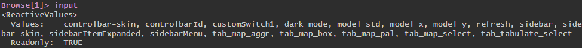

Accessing `input` in Shiny browser call

## 2.2 Logging

- In base R, print debugging is frowned upon
- In Shiny, print debugging can be a nice way to understand errors along a reactivity path (or to understand reactivity in general)

## 2.3 Where am I?

- That is a question you might ask yourself occasionally when encountering errors in Shiny
- The [`whereami`](https://cran.r-project.org/web/packages/whereami/) package can tell you exactly where you are
- Many R packages enable general logging ([`logging`](https://cran.rstudio.com/web/packages/logging/), [`logger`](https://cran.r-project.org/web/packages/logger/), [`log4r`](https://cran.r-project.org/web/packages/log4r)), but `whereami` is especially suitable for Shiny

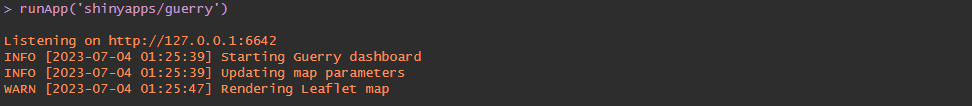

Logs from `logger`

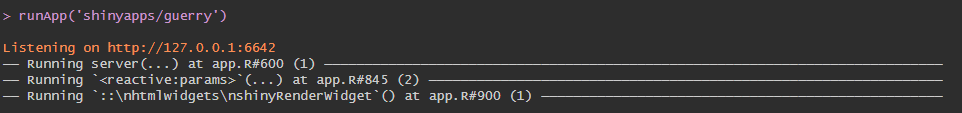

Logs from `whereami`

## 2.4 Reactivity logging

- Reactivity logging means capturing and visualizing reactive dependencies in Shiny apps
- Useful for detecting overreactiveness and reactive **instabilities**
- Reactivity logging can be done using the [`reactlog`](https://rstudio.github.io/reactlog/) package

### 2.4.1 Using the `reactlog` package

- Run [`reactlog::reactlog_enable()`](https://rstudio.github.io/reactlog/reference/setReactLog.html) before running the Shiny app or set `options(shiny.reactlog = TRUE)`
- Do stuff in your Shiny app (particularly something that triggers dependencies!)
- Run [`shiny::reactlogShow()`](https://shiny.posit.co/r/reference/shiny/1.3.1/reactlog.html) or [`reactlog::reactlog_show()`](https://rstudio.github.io/reactlog/reference/reactlog_show.html) after closing the app
- Alternatively, press `Strg + F3` while the app is running

[interactive chart not shown]

# 3 Deployment

- The deployment of Shiny apps is restricted to servers that support Shiny apps
- You can either set up a custom Shiny server or use a server provider

## 3.1 Deployment options

Shiny app hosting

| Name | Use | Requirements |
| --- | --- | --- |
| [shinyapps.io](https://www.shinyapps.io/) | Casual to professional applications | `rsconnect` R package |
| [Posit Connect](https://posit.co/products/enterprise/connect/) | Professional to corporate applications | `rsconnect` R package |
| [Shiny Server](https://posit.co/products/open-source/shinyserver/) / self-hosting | Setting up self-hosted Shiny servers | Shiny Server on a Linux server |
| [ShinyProxy](https://www.shinyproxy.io/) / [Heroku](https://www.heroku.com/) / [Hugging Face](https://huggingface.co/docs/hub/spaces-sdks-docker-shiny) | Deployment of containerized applications | Docker |
| [Shinylive](https://posit-dev.github.io/r-shinylive/) | Simple applications in an embedded setting | An existing static website |
| GitHub / CRAN / BioConductor | Applications for researchers or developers | Proficiency in R package development |

# 4 Shinylive

- [Shinylive](https://posit-dev.github.io/r-shinylive/) is one of Posit’s new things
- An application deployed with Shinylive does not need a server: It is a static website!
- This is possible primarily due to developments in what is called [**WebAssembly**](https://en.wikipedia.org/wiki/WebAssembly) **(Wasm)**
- If you are interested in the magic behind Shinylive and Wasm, check out Joe Cheng’s talk at posit::conf(2023)

[video not shown]

## 4.1 Whats so cool about Shinylive?

- You can simply embed your Shiny app:
  - In your personal website
  - In your Quarto/RMarkdown document
  - In your package documentation
  - In another Shiny app (do try this at home)

## 4.2 R packages

- Running R in the web is powered by the [WebR framework](https://docs.r-wasm.org/webr/latest/)
- Not all R (or Python) packages are available in WebR
  - R packages need to be built for wasm
  - If a package’s dependency cannot be built for wasm, it is not usable
  - Only binary packages can be built
  - Some features simply do not work:
    - `system()` or any other system commands
    - Database connections
    - Parallelization
- You can check which packages are built for wasm [here](https://repo.r-wasm.org/) (currently about 14,000 packages are available)

## 4.3 Other Limitations

- Can be quite slow on startup
- Code and data are fully visible in the source code (thus not useful for sensitive data)
- App runs on the client machine and can thus be very slow and demanding
- The framework is in early development and debugging can be a real hassle

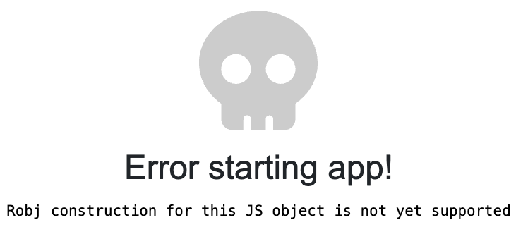

A common Shinylive error

## 4.4 Downloading assets

- Shinylive is actually a library of web assets that run R in the background
- The `shinylive` package needs these assets to turn a Shiny app into HTML code

```r
library(shinylive)
assets_ensure()
assets_info()
```

## 4.5 Creating the app

```r
export("shinyapps/example", destdir = "shinyapps/example/shinylive")
```

- In theory, the resulting HTML document can now simply be opened
- In practice, however, the HTML document must be opened on a static server, e.g. using the `httpuv` package:

```r
httpuv::runStaticServer("shinyapps/example/shinylive", port = httpuv::randomPort())
```

## 4.6 Embed Shinylive in Quarto

- Quarto supports Shinylive through the `shinylive` extension

```r
quarto::quarto_add_extension("quarto-ext/shinylive", no_prompt = TRUE)
```

- In the YAML header, specify the `filters` keyword

```
filters:
  - shinylive
```

- Shinylive code chunks must be marked with `shinylive-r` or `shinylive-python`
- Four additional options are defined:
  - `standalone` specifies that the code chunk contains an entire app
  - `components` specifies whether to show a code editor next to the rendered app
  - `layout` specifies whether to show the components vertically or horizontally aligned
  - `viewerHeight` specifies the height of the app viewer in pixels

# 5 shinyapps.io

- A common choice for more casual Shiny apps is shinyapps.io
  - It requires not much technical knowledge to deploy
  - It does not require a pre-existing infrastructure (e.g., a server)
  - It offers a free plan

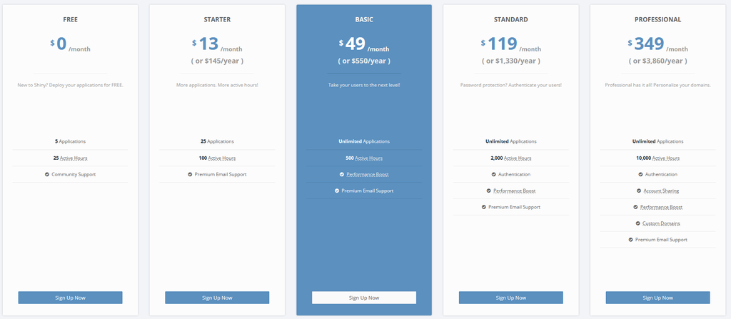

Shinyapps.io plans

## 5.1 `rsconnect`

- Both for Posit Connect and shinyapps.io you need the [`rsconnect`](https://rstudio.github.io/rsconnect/) package
- `rsconnect` enables the communication between the Posit services and R
- `rsconnect` is built around the [`deployApp()`](https://rstudio.github.io/rsconnect/reference/deployApp.html), [`deployAPI()`](https://rstudio.github.io/rsconnect/reference/deployAPI.html) and [`deployDoc()`](https://rstudio.github.io/rsconnect/reference/deployDoc.html) functions

## 5.2 Creating an account

- Before being able to deploy to Shinyapps, we need an account
- Accounts can be created per Email or using Google, Github or Clever

[figure not shown]

Shinyapps.io sign-up

## 5.3 Connecting R to shinyapps.io

- Just with any interface, linking works using Tokens and Secrets
- On your shinyapps dashboard, navigate to Account -> Tokens on the sidebar
- Click on “Add Token”
- Click on “Show” next to your newly created token
- Paste the code into your console and execute

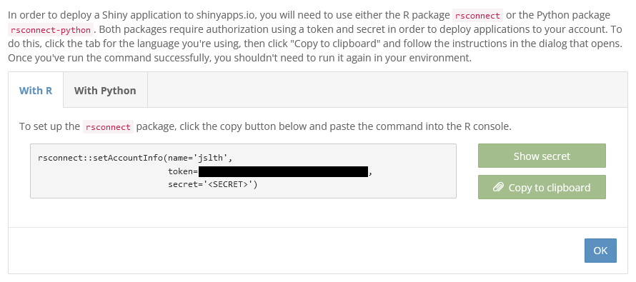

Shinyapps token to connect with `rsconnect`

## 5.4 Deploy!

- To verify that the verification process was successful we run:

```r
rsconnect::accounts()
```

- Finally, to deploy an app, we simply run `deployApp()` to deploy an `app.R` in the current working directory to shinyapps.io:

```r
rsconnect::deployApp()
```

# 6 Appendix: Performance profiling

- Profiling means recording how much time and memory certain actions in your Shiny app need
- Useful for testing performance or **speed** of your app
- Performance profiling in Shiny can be done with the `profvis` package

## 6.1 Interpreting flame graphs

- Flame graphs are a tool to quickly visualize performance of individual parts of an app
- They consist of two-dimensional “function boxes” which represent an individual function call
  - The **width** of a function box indicates the time it took to process the function call
  - The **stacked height** of function boxes indicates their ancestry. The lower boxes are the parents and the upper boxes are their children, i.e. the lower boxes call the upper boxes

[figure not shown]

The concept of a flame graph

## 6.2 Using the `profvis` package

- Simply run your app within a `profvis::profvis()` call:

```r
profvis({runApp()})
```

**Note**

It is necessary to use `runApp()`, `shinyApp()` does not suffice!

- Then, perform some tasks in the Shiny app
- Close the app and a flame graph will be created
- Note the color scheme:
  - Yellow boxes correspond to specific lines in the code
  - Blue boxes correspond to output objects
  - Grey boxes correspond to garbage collection

[interactive chart not shown]

# 7 Exercises

**Exercise 1**

Export your Shiny app as a static Shinylive webpage using the `shinylive` package.

To prevent problems ahead of time, make sure that you are running the newest version of the Shinylive package and web assets. The latest `shinylive` version can be downloaded from GitHub:

```r
# pak::pkg_install("posit-dev/r-shinylive")
packageVersion("shinylive")
```

```
[1] '0.1.1.9000'
```

The latest assets version can be retrieved using `shinylive::assets_version()`

```r
# assets_ensure()
assets_version()
```

```
[1] "0.3.0"
```

**Exercise 2**

Deploy your Shiny app using shinyapps.io. If necessary, create an account, and then follow the instructions.

Study the documentation of `?rsconnect::deployApp()` to learn about possible deployment configurations.